# Análse dos dados da Remax

Sequência: 1 - Análise factorial: excluir o preço e procurar reduzir o nr de variáveis através da identificação de novos eixos factoriais, não correlaccionados. 2 - Análise de regressao múltipla, dependência 1 variável quantitativa

Ler dados

```r
imoveis <- read.csv(file="Remax data_revised_UTF8.csv", sep=";", dec=",", strip.white = TRUE)
```

Ver os dados

Fazer para exibir caracteres correctamente

```r
Sys.setlocale(category = "LC_ALL", locale = "pt_PT.UTF-8")
```

```
[1] "pt_PT.UTF-8/pt_PT.UTF-8/pt_PT.UTF-8/C/pt_PT.UTF-8/C"
```

Número de observações por categoria energética

```r
table(imoveis$erate)
```

```
          A    A+     B    B-     C     D     E     F     G    NC
   14  1246   325  2730   259  3149  1933   943   436   138 20110
```

Criar novo subset de imoveis contendo apenas as instâncias que têm classe energetica definida

```r
imo<-subset(imoveis, erate!="NC" & erate!="")
# ou
# imo<-imoveis[imoveis["erate"]!="",]
# imo<-imo[imo["erate"]!="NC",]
```

Número de observações por categoria energética do novo subset (apenas com classe energetica)

```r
table(imo$erate)
```

```
        A   A+    B   B-    C    D    E    F    G   NC
   0 1246  325 2730  259 3149 1933  943  436  138    0
```

Criar funcao para converter strings de colunas para numericos

```r
convert.to.numeric <- function(var) {
  result <- var
  result <- gsub("\\.", "", result)    # Remove os "."
  result <- gsub(",", ".", result)     # Substitui as "," por "."
  result <- gsub("[^0-9,.-]", "", result) # Remove todos caracteres não numericos excluindo ainda ","  "." e "-"
  result <- as.numeric(result)
}
```

Converter as variaveis Preco, AreaContrucaoM2, TamLoteM2, TotalM2 para numerico

```r
imo$preco <- convert.to.numeric(imo$preco)
imo$AreaConstrucaoM2 <- convert.to.numeric(imo$AreaConstrucaoM2)
imo$TamLoteM2 <- convert.to.numeric(imo$TamLoteM2)
imo$TotalM2 <- convert.to.numeric(imo$TotalM2)
```

Converte as variáveis lat e lng para numerico

```r
imo$lat <- as.numeric(gsub("[^0-9.-]", "", imo$lat))
imo$lng <- as.numeric(gsub("[^0-9.-]", "", imo$lng))
```

Nota: No gsub quando se utiliza o ponto assim “[.]” não é necessário colocar os escapes “\”

Converter as variaveis titulo, desc, e url para character

```r
imo$titulo <- as.character(imo$titulo)
imo$desc <- as.character(imo$desc)
imo$url <- as.character(imo$url)
```

Verificar a estrutura do dataset:

```r
str(imo)
```

```
'data.frame':   11159 obs. of  18 variables:
 $ index                : int  3 15 20 23 26 27 29 34 36 41 ...
 $ titulo               : Factor w/ 20472 levels "","                \" No centro de Alverca a 5m de C.P",..: 765 3140 3561 2652 1427 1 2714 2730 1 9120 ...
 $ preco                : num  300000 298000 190000 102000 298000 550000 86000 108000 350000 1080000 ...
 $ desc                 : Factor w/ 27626 levels "","\001T3 Duplex perto de São João da Madeira com cozinha totalmente equipada( forno,placa maquina de lavar louça,frigorifico,micr"| __truncated__,..: 25774 2895 27337 3084 12271 22515 3252 8095 9125 18481 ...
 $ erate                : Factor w/ 11 levels "","A","A+","B",..: 4 6 6 7 6 7 6 6 6 2 ...
 $ lat                  : num  -20.6 32.6 32.6 32.6 32.6 ...
 $ lng                  : num  -41.2 -16.9 -16.9 -16.9 -16.9 ...
 $ TotalM2              : num  96 236 116 88 235 253 75 82 270 450 ...
 $ Quartos              : int  2 3 3 1 4 3 1 1 4 3 ...
 $ Casas.Banho          : int  1 3 NA 1 3 4 1 1 3 5 ...
 $ AnoConstrucao        : int  1920 2003 2001 1994 2007 2009 2000 2011 1996 2009 ...
 $ TotalAssoalhadas     : int  5 6 4 2 5 4 2 2 5 8 ...
 $ TamLoteM2            : num  96 NA NA NA 235 ...
 $ NrAndar              : Factor w/ 23 levels "","1-20","1º Andar",..: 4 1 1 5 1 1 1 4 1 1 ...
 $ LugaresEstacionamento: int  NA 2 NA NA 3 NA NA NA NA NA ...
 $ NrPisos              : int  NA 2 NA NA NA NA NA NA NA 3 ...
 $ AreaConstrucaoM2     : num  75 NA NA NA NA NA NA NA NA NA ...
 $ url                  : Factor w/ 31283 levels "http://www.remax.pt/120061120-1",..: 25417 4433 18698 22317 4692 19325 28666 28619 13854 27255 ...
```

Nota: A variável de class. energética (erate) é uma variável ordinal (qualitativa com ordenação)

Análise dos outliers:

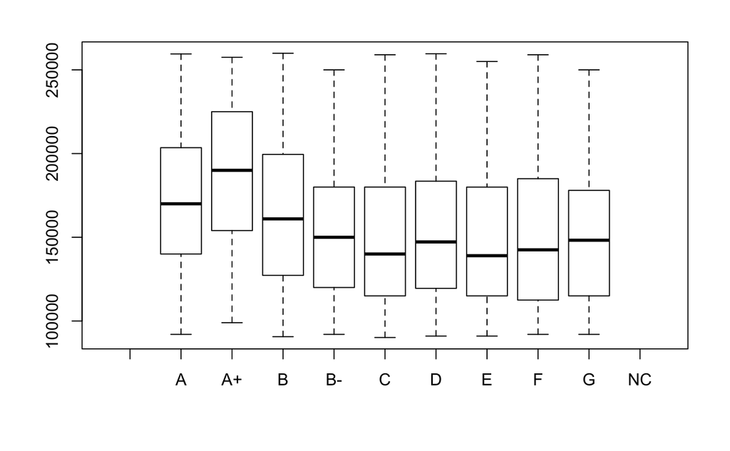

```r
imo.quartis <- quantile(imo$preco,c(0.25, 0.5, 0.75), na.rm = "TRUE") #[1] <- 1º quartil [3] <- 3º quartil
imo.sem.outls.preco <- subset(imo, preco>imo.quartis[1] & preco<imo.quartis[3])
boxplot(imo.sem.outls.preco$preco~imo.sem.outls.preco$erate)
```

Análise dos dados

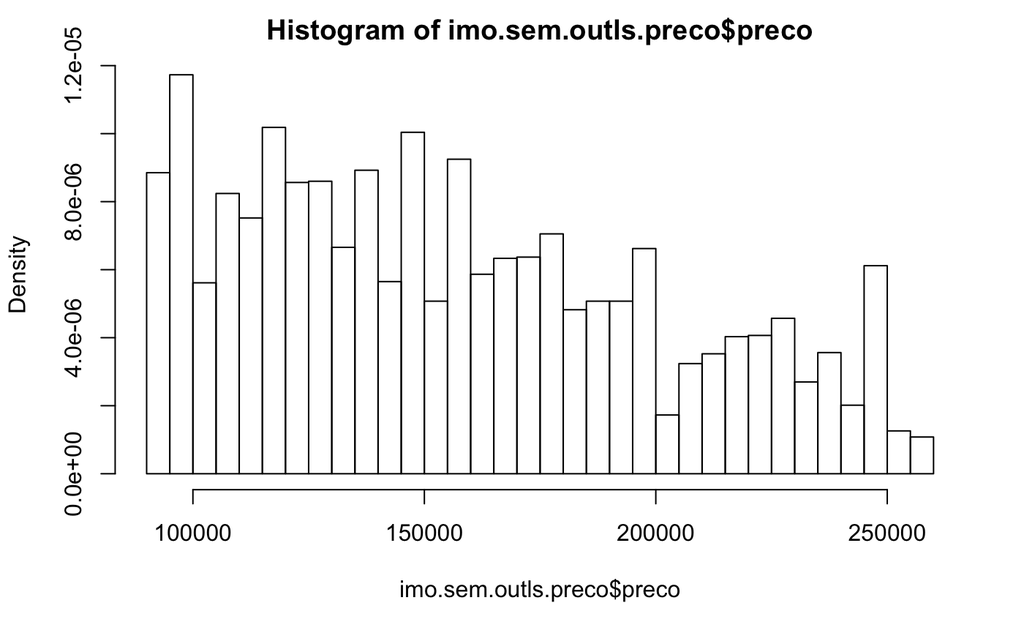

```r
hist(imo.sem.outls.preco$preco, prob = TRUE, breaks = 40)
```

```r
# lines(density(imo$preco, na.rm = TRUE))
```

Guardar ficheiro

```r
options(scipen=500)
write.csv2(imo, "RemaxData_IntermResults.csv")
```

```r
anova(lm(imo$preco~imo$erate))
```

```
Analysis of Variance Table

Response: imo$preco
             Df     Sum Sq    Mean Sq F value    Pr(>F)
imo$erate     8 5.0192e+13 6.2740e+12  94.281 < 2.2e-16 ***
Residuals 11150 7.4199e+14 6.6546e+10
---
Signif. codes:  0 ‘***’ 0.001 ‘**’ 0.01 ‘*’ 0.05 ‘.’ 0.1 ‘ ’ 1
```